Connect Wallet

# Check TON transactions and manage risks

TON AML CHECK is the first cloud-based solution for the TON blockchain, leveraging AI-driven tools to analyze wallets and transactions. Reduce manual efforts, financial risks, and protect your business's reputation.

[figure not shown]

[figure not shown]

## Game-Changing Solution

The platform is powered by advanced machine learning algorithms that continuously optimize and enhance its capabilities.

- Real-time data  
  update
- Detailed wallet  
  statistics
- Data-driven  
  Insights
- Fast API  
  integration

## Advanced Risk Scorer

- It aids fintech companies and their AML officers in verifying TON addresses and making informed KYT decisions guided by data.

[figure not shown]

## Smart Visualizer

- This tool simplifies comprehensive investigations into crypto asset origins, transaction history, and destinations.

[figure not shown]

## Fast API integration

- This enables developers from any company to seamlessly integrate risk assessment functionality into their projects.

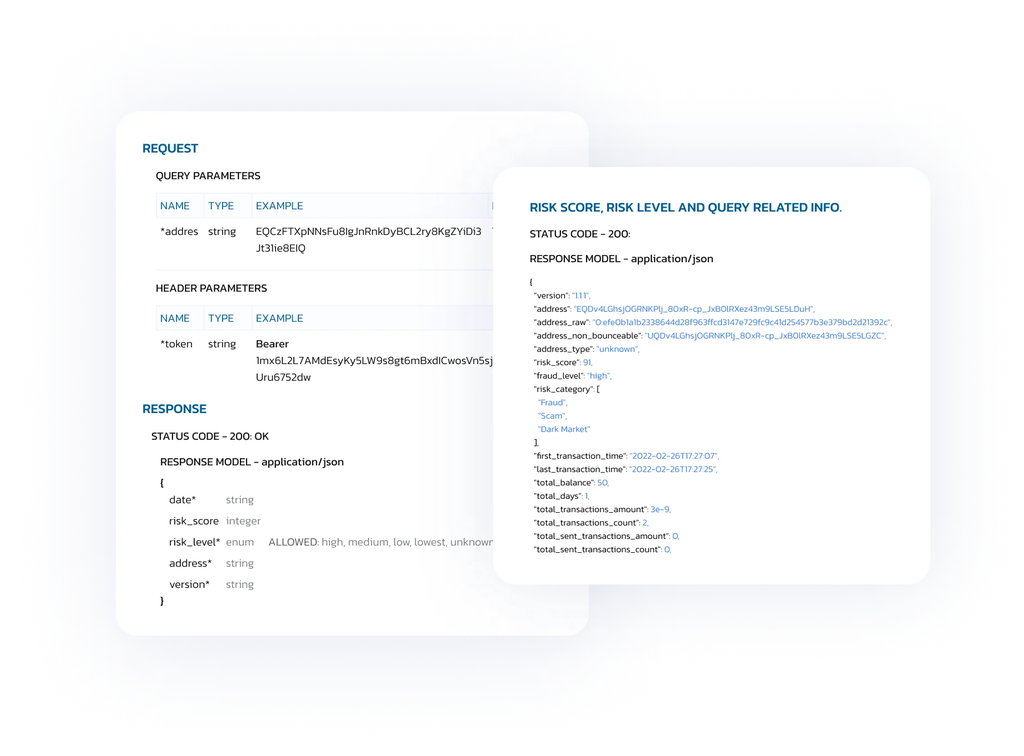

## Evaluate risks better

Discover effective detection of suspicious TON blockchain  
transactions with our solutions.

Connect wallet

## FAQ

### How is risk level determined in your system?

- The risk level is determined by evaluating multiple factors, such as transaction history, wallet behavior, and known fraudulent patterns. It provides insights into the likelihood of wallet involvement in dishonest activities within the TON blockchain.

### What kind of data sources does your system utilize for risk assessment?

- TON AML CHECK leverages a variety of data sources for risk assessment. This includes transaction data from the TON blockchain, information provided by our clients' compliance departments, and open-source data about blockchain addresses, wallet types, and more. By incorporating multiple data sources, the accuracy and efficiency of the systemic risk assessment process are increased.

### How often is the risk assessment updated in your system?

- The system provides real-time risk assessment updates. As new transactions occur on the TON blockchain, developed algorithms continuously analyze and update the risk scores associated with wallets. This ensures that you have the latest information for well-informed decisions and swift actions.

### Can your system integrate with existing compliance and AML processes within my organization?

- TON AML CHECK is designed to integrate with existing compliance and anti-money laundering (AML) processes by API and in personal accounts. It can work in conjunction with your organization's compliance departments, providing valuable insights to support risk management and regulatory compliance efforts.